[figure not shown]

# PCA and t-SNE Project: Auto MPG

## **Marks: 30**

## **Context**

The shifting market conditions, globalization, cost pressure, and volatility are leading to a change in the automobile market landscape. The emergence of data, in conjunction with machine learning in automobile companies, has paved a way that is helping bring operational and business transformations.

The automobile market is vast and diverse, with numerous vehicle categories being manufactured and sold with varying configurations of attributes such as displacement, horsepower, and acceleration. We aim to find combinations of these features that can clearly distinguish certain groups of automobiles from others through this analysis, as this will inform other downstream processes for any organization aiming to sell each group of vehicles to a slightly different target audience.

You are a Data Scientist at SecondLife which is a leading used car dealership with numerous outlets across the US. Recently, they have started shifting their focus to vintage cars and have been diligently collecting data about all the vintage cars they have sold over the years. The Director of Operations at SecondLife wants to leverage the data to extract insights about the cars and find different groups of vintage cars to target the audience more efficiently.

## **Objective**

The objective of this problem is to **explore the data, reduce the number of features by using dimensionality reduction techniques like PCA and t-SNE, and extract meaningful insights**.

## **Dataset**

There are 8 variables in the data:

- mpg: miles per gallon
- cyl: number of cylinders
- disp: engine displacement (cu. inches) or engine size
- hp: horsepower
- wt: vehicle weight (lbs.)
- acc: time taken to accelerate from 0 to 60 mph (sec.)
- yr: model year
- car name: car model name

### Importing the necessary libraries and overview of the dataset

```python
# Import all necessary libraries useful for this project:

import pandas as pd

import seaborn as sns

import numpy as np

import matplotlib.pyplot as plt

from sklearn.preprocessing import StandardScaler

from sklearn.decomposition import PCA # Relevant*

from sklearn.manifold import TSNE # Relevant*

import warnings
warnings.filterwarnings("ignore") # still, important
```

### **Loading the data**

```python
cars = pd.read_csv('auto-mpg.csv')
```

```python
cars.head(2)
```

|  | mpg | cylinders | displacement | horsepower | weight | acceleration | model year | car name |
| --- | --- | --- | --- | --- | --- | --- | --- | --- |
| 0 | 18.0 | 8 | 307.0 | 130 | 3504 | 12.0 | 70 | chevrolet chevelle malibu |
| 1 | 15.0 | 8 | 350.0 | 165 | 3693 | 11.5 | 70 | buick skylark 320 |

```python
cars.sample(10, random_state = 2)
```

|  | mpg | cylinders | displacement | horsepower | weight | acceleration | model year | car name |
| --- | --- | --- | --- | --- | --- | --- | --- | --- |
| 94 | 13.0 | 8 | 440.0 | 215 | 4735 | 11.0 | 73 | chrysler new yorker brougham |
| 32 | 25.0 | 4 | 98.0 | ? | 2046 | 19.0 | 71 | ford pinto |
| 279 | 29.5 | 4 | 98.0 | 68 | 2135 | 16.6 | 78 | honda accord lx |
| 178 | 23.0 | 4 | 120.0 | 88 | 2957 | 17.0 | 75 | peugeot 504 |
| 354 | 34.5 | 4 | 100.0 | ? | 2320 | 15.8 | 81 | renault 18i |
| 25 | 10.0 | 8 | 360.0 | 215 | 4615 | 14.0 | 70 | ford f250 |
| 67 | 11.0 | 8 | 429.0 | 208 | 4633 | 11.0 | 72 | mercury marquis |
| 188 | 16.0 | 8 | 318.0 | 150 | 4190 | 13.0 | 76 | dodge coronet brougham |
| 157 | 15.0 | 8 | 350.0 | 145 | 4440 | 14.0 | 75 | chevrolet bel air |
| 225 | 17.5 | 6 | 250.0 | 110 | 3520 | 16.4 | 77 | chevrolet concours |

```python
cars.info()
```

```
<class 'pandas.core.frame.DataFrame'>
RangeIndex: 398 entries, 0 to 397
Data columns (total 8 columns):
 #   Column        Non-Null Count  Dtype
---  ------        --------------  -----
 0   mpg           398 non-null    float64
 1   cylinders     398 non-null    int64
 2   displacement  398 non-null    float64
 3   horsepower    398 non-null    object
 4   weight        398 non-null    int64
 5   acceleration  398 non-null    float64
 6   model year    398 non-null    int64
 7   car name      398 non-null    object
dtypes: float64(3), int64(3), object(2)
memory usage: 25.0+ KB
```

```python
horsepower2 = pd.DataFrame(cars.horsepower.str.isdigit())

cars[horsepower2['horsepower'] == False]
```

|  | mpg | cylinders | displacement | horsepower | weight | acceleration | model year | car name |
| --- | --- | --- | --- | --- | --- | --- | --- | --- |
| 32 | 25.0 | 4 | 98.0 | ? | 2046 | 19.0 | 71 | ford pinto |
| 126 | 21.0 | 6 | 200.0 | ? | 2875 | 17.0 | 74 | ford maverick |
| 330 | 40.9 | 4 | 85.0 | ? | 1835 | 17.3 | 80 | renault lecar deluxe |
| 336 | 23.6 | 4 | 140.0 | ? | 2905 | 14.3 | 80 | ford mustang cobra |
| 354 | 34.5 | 4 | 100.0 | ? | 2320 | 15.8 | 81 | renault 18i |
| 374 | 23.0 | 4 | 151.0 | ? | 3035 | 20.5 | 82 | amc concord dl |

```python
cars = cars.replace('?', np.nan)
```

```python
# Imputing the missing values with the median value of the column horsepower
cars.horsepower.fillna(cars.horsepower.median(), inplace = True)

# Converting the horsepower column from object data type to float
cars['horsepower'] = cars['horsepower'].astype('float64')
```

```python
cars.info()
```

```
<class 'pandas.core.frame.DataFrame'>
RangeIndex: 398 entries, 0 to 397
Data columns (total 8 columns):
 #   Column        Non-Null Count  Dtype
---  ------        --------------  -----
 0   mpg           398 non-null    float64
 1   cylinders     398 non-null    int64
 2   displacement  398 non-null    float64
 3   horsepower    398 non-null    float64
 4   weight        398 non-null    int64
 5   acceleration  398 non-null    float64
 6   model year    398 non-null    int64
 7   car name      398 non-null    object
dtypes: float64(4), int64(3), object(1)
memory usage: 25.0+ KB
```

```python
cars.duplicated().sum()
```

```
0
```

```python
cars["car name"].nunique()
```

```
305
```

```python
cars = cars.drop(["car name"], axis = 1)
```

```python
cars.info()
```

```
<class 'pandas.core.frame.DataFrame'>
RangeIndex: 398 entries, 0 to 397
Data columns (total 7 columns):
 #   Column        Non-Null Count  Dtype
---  ------        --------------  -----
 0   mpg           398 non-null    float64
 1   cylinders     398 non-null    int64
 2   displacement  398 non-null    float64
 3   horsepower    398 non-null    float64
 4   weight        398 non-null    int64
 5   acceleration  398 non-null    float64
 6   model year    398 non-null    int64
dtypes: float64(4), int64(3)
memory usage: 21.9 KB
```

### **Observations:**

1. We treated the question marks replacing them with np.nan
2. the horsepower column type was changed from obj to float.
3. We dropped the car name column from the dataset. It would not make a difference in the analysis.
4. There are no duplicates in the dataset.

### Data Preprocessing and Exploratory Data Analysis

### **Summary Statistics**

```python
cars.describe(include = 'all').T
```

|  | count | mean | std | min | 25% | 50% | 75% | max |
| --- | --- | --- | --- | --- | --- | --- | --- | --- |
| mpg | 398.0 | 23.514573 | 7.815984 | 9.0 | 17.500 | 23.0 | 29.000 | 46.6 |
| cylinders | 398.0 | 5.454774 | 1.701004 | 3.0 | 4.000 | 4.0 | 8.000 | 8.0 |
| displacement | 398.0 | 193.425879 | 104.269838 | 68.0 | 104.250 | 148.5 | 262.000 | 455.0 |
| horsepower | 398.0 | 104.304020 | 38.222625 | 46.0 | 76.000 | 93.5 | 125.000 | 230.0 |
| weight | 398.0 | 2970.424623 | 846.841774 | 1613.0 | 2223.750 | 2803.5 | 3608.000 | 5140.0 |
| acceleration | 398.0 | 15.568090 | 2.757689 | 8.0 | 13.825 | 15.5 | 17.175 | 24.8 |
| model year | 398.0 | 76.010050 | 3.697627 | 70.0 | 73.000 | 76.0 | 79.000 | 82.0 |

### **Observations:**

```
mpg
Skew : 0.46
```

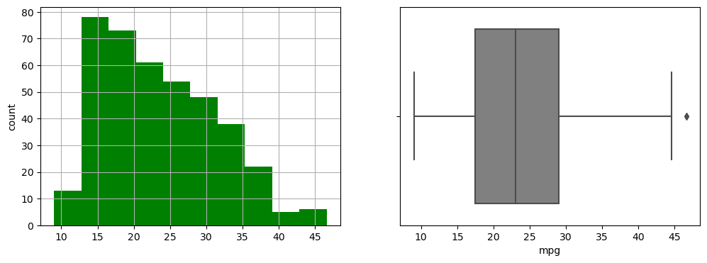

```
cylinders
Skew : 0.53
```

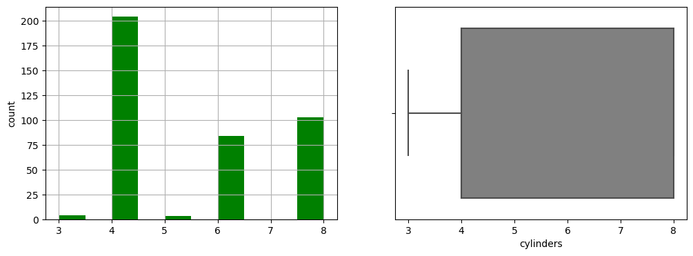

```
displacement
Skew : 0.72
```

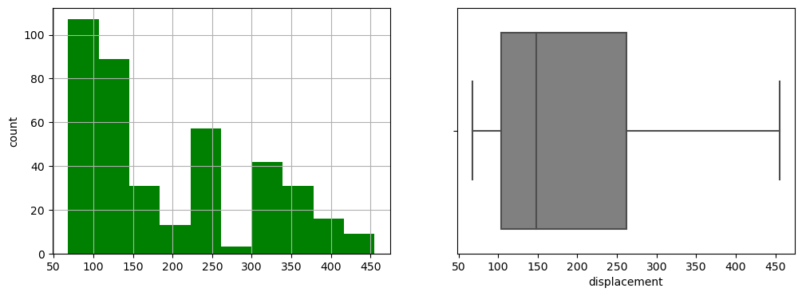

```
horsepower
Skew : 1.11
```

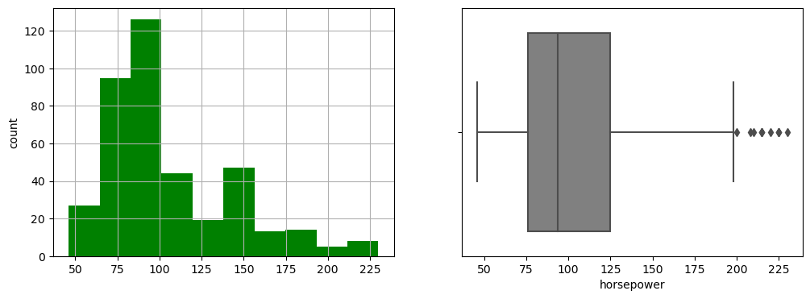

```
weight
Skew : 0.53
```

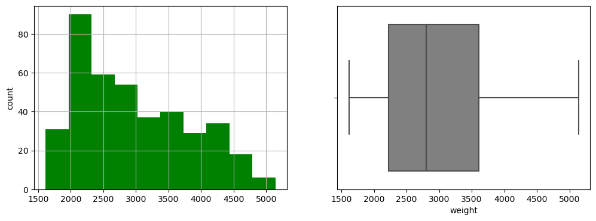

```
acceleration
Skew : 0.28
```

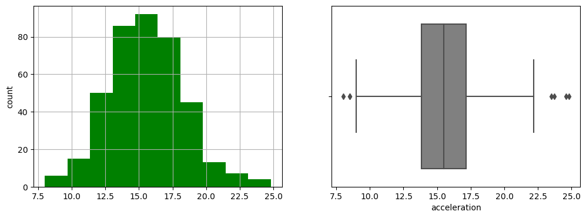

```
model year
Skew : 0.01
```

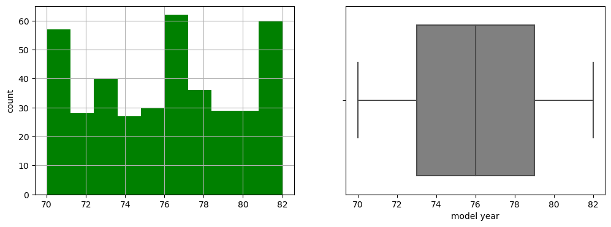

```python
num_cols = list(cars.columns)

for col in num_cols:

    print(col)

    print('Skew :',round(cars[col].skew(),2))

    plt.figure(figsize = (12, 4))

    plt.subplot(1, 2, 1)

    cars[col].hist(bins = 10, grid = True, color = 'green')# nice color histogram

    plt.ylabel('count')

    plt.subplot(1, 2, 2)

    sns.boxplot(x = cars[col], color = 'gray') # another nice color boxplot...outliers

    plt.show()
```

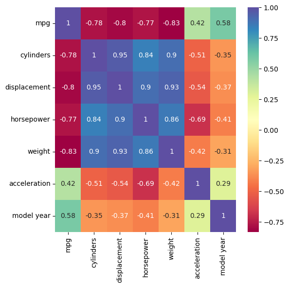

```python
plt.figure(figsize = (6, 6))
sns.heatmap(cars.corr(), annot = True, cmap = "Spectral")# scectral...yes please!
plt.xticks(rotation = 90)# easier to read
plt.show()
```

### **OBSERVATIONS:**

**High positive correlation:**

**High Negative:**

### **Scaling the data**

```python
# Scaling cars
scaler = StandardScaler()

cars_scaled = pd.DataFrame(scaler.fit_transform(cars), columns = cars.columns)
```

```python
cars_scaled.head()
```

|  | mpg | cylinders | displacement | horsepower | weight | acceleration | model year |
| --- | --- | --- | --- | --- | --- | --- | --- |
| 0 | -0.706439 | 1.498191 | 1.090604 | 0.673118 | 0.630870 | -1.295498 | -1.627426 |
| 1 | -1.090751 | 1.498191 | 1.503514 | 1.589958 | 0.854333 | -1.477038 | -1.627426 |
| 2 | -0.706439 | 1.498191 | 1.196232 | 1.197027 | 0.550470 | -1.658577 | -1.627426 |
| 3 | -0.962647 | 1.498191 | 1.061796 | 1.197027 | 0.546923 | -1.295498 | -1.627426 |
| 4 | -0.834543 | 1.498191 | 1.042591 | 0.935072 | 0.565841 | -1.840117 | -1.627426 |

## **Principal Component Analysis**

```python
# Number of principal components
n = cars_scaled.shape[1]

# Finding principal components for the data
pca1 = PCA(n_components = n, random_state = 1)
cars_pca = pd.DataFrame(pca1.fit_transform(cars_scaled))

# The percentage of variance explained by each principal component
exp_var = pca1.explained_variance_ratio_
```

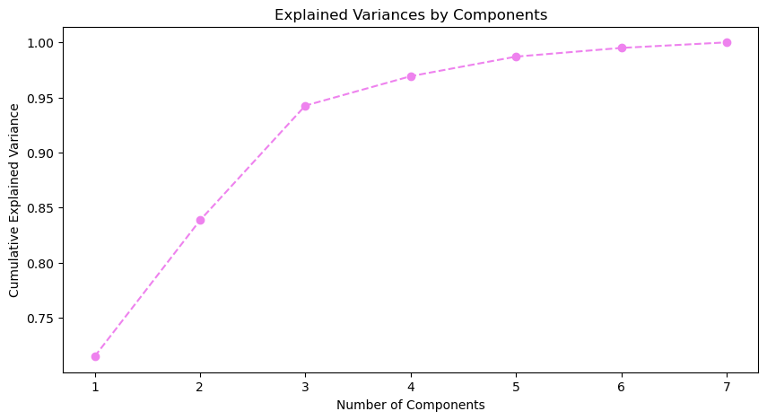

```python
plt.figure(figsize = (10, 5))

plt.plot(range(1, 8), pca1.explained_variance_ratio_.cumsum(), marker = 'o', linestyle = '--', color = 'violet')

plt.title("Explained Variances by Components")

plt.xlabel("Number of Components")

plt.ylabel("Cumulative Explained Variance")

plt.show()
```

```python
# Finding the least number of components that can explain more than 90% variance
sum = 0

for ab, a in enumerate(exp_var):

    sum = sum + a

    if(sum>0.90):

        print("number of PCs that explain at least 90% variance:", ab + 1)
        break
```

```
number of PCs that explain at least 90% variance: 3
```

#### **Interpret the coefficients of the first three principal components from the below DataFrame**

```python
pc_comps = ['PC1', 'PC2', 'PC3'] # 3 is the number of componets

data_pca = pd.DataFrame(np.round(pca1.components_[:3,:],2), index = pc_comps, columns = cars_scaled.columns)

data_pca.T
```

|  | PC1 | PC2 | PC3 |
| --- | --- | --- | --- |
| mpg | -0.40 | -0.21 | -0.26 |
| cylinders | 0.42 | -0.19 | 0.14 |
| displacement | 0.43 | -0.18 | 0.10 |
| horsepower | 0.42 | -0.09 | -0.17 |
| weight | 0.41 | -0.22 | 0.28 |
| acceleration | -0.28 | 0.02 | 0.89 |
| model year | -0.23 | -0.91 | -0.02 |

```python
#2D for easier vizualization. made it colorful.

def color_high(val):

    if val < -0.25:
        return 'background: gray'

    elif val > 0.25:
        return 'background: orange'

data_pca.T.style.applymap(color_high)
```

|  | PC1 | PC2 | PC3 |
| --- | --- | --- | --- |
| mpg | -0.400000 | -0.210000 | -0.260000 |
| cylinders | 0.420000 | -0.190000 | 0.140000 |
| displacement | 0.430000 | -0.180000 | 0.100000 |
| horsepower | 0.420000 | -0.090000 | -0.170000 |
| weight | 0.410000 | -0.220000 | 0.280000 |
| acceleration | -0.280000 | 0.020000 | 0.890000 |
| model year | -0.230000 | -0.910000 | -0.020000 |

### **Observations:**

3.The third principal component, PC3, seems to be a negative correlation with PC1(-.28) and a strong positive contribution with PC3 (.89).

1. The positive co-efficient values establishe the underlaying relationship of cylinders, displacement, horsepower and weight **in one word: Speed**
2. The negative co-efficient values indicate that miles per galon and acceleration are similarly negatively co-efficent.

## **t-SNE**

```python
# Fitting t-SNE with number of components equal to 2
tsne = TSNE(n_components = 2, random_state = 1)

cars_tsne = tsne.fit_transform(cars_scaled)
```

```python
cars_tsne = pd.DataFrame(cars_tsne, columns = ['a1', 'a2']) # chose this a instead of x to represent the columns.
```

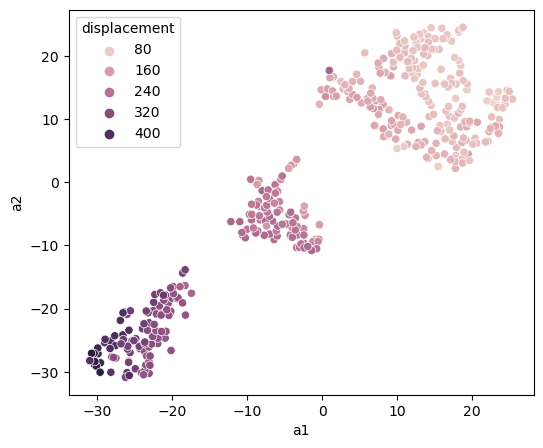

```python
# Scatter plot for two components
plt.figure(figsize = (6,5))

sns.scatterplot(x = 'a1', y = 'a2', data = cars_tsne, hue=cars.displacement)

plt.show()
```

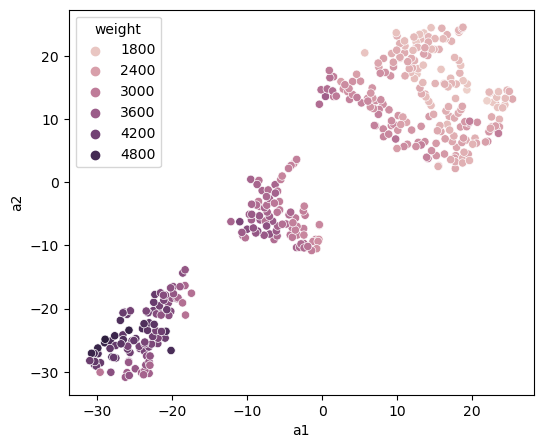

```python
# Scatter plot for two components
plt.figure(figsize = (6,5))

sns.scatterplot(x = 'a1', y = 'a2', data = cars_tsne, hue=cars.weight)

plt.show()
```

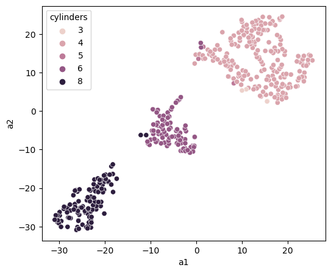

```python
# Scatter plot for two components
plt.figure(figsize = (6,5))

sns.scatterplot(x = 'a1', y = 'a2', data = cars_tsne, hue=cars.cylinders)

plt.show()
```

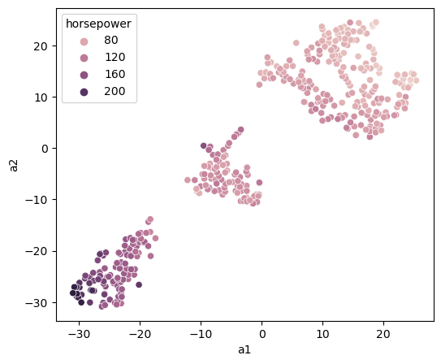

```python
# Scatter plot for two components
plt.figure(figsize = (6,5))

sns.scatterplot(x = 'a1', y = 'a2', data = cars_tsne, hue=cars.horsepower)

plt.show()
```

## **Observations:**

**3 main groups with 4 correlated features**

1.Displacement:low of 80 high of 400

2.Weight: low 1800 high 4800

3.Cylinders: low 3 high 8

4.Horsepower: low of 80 high of 200

**The majority of the cars are the lower numbers of the spectrum. The second place is the highest of the spectrum meaning heavier, more cylinders...etc The fewer cars fall in the middle of the scales.**

```python
cars_tsne = pd.DataFrame(data = cars_tsne, columns = ['a1', 'a2'])
```

```python
# Let's assign points to 3 different groups
def grouping(x):
    first_component = x['a1']

    second_component = x['a2']

    if (first_component > 0) and (second_component > -5):
        return 'group_1'

    if (first_component > -20 ) and (first_component < 5):
        return 'group_2'

    else:
        return 'group_3'
```

#### **Visualize the clusters w.r.t different variables using scatter plot and box plot**

```python
cars_tsne['groups'] = cars_tsne.apply(grouping, axis = 1)
```

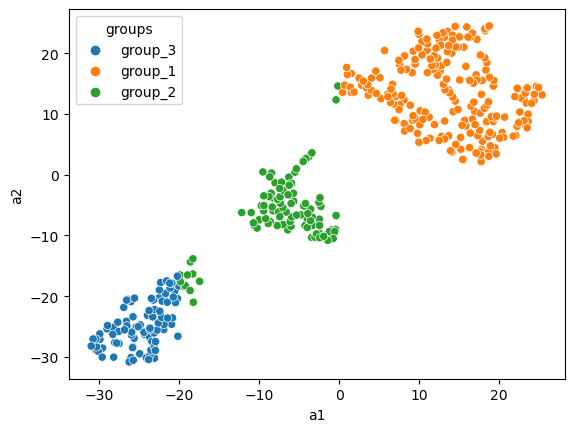

```python
sns.scatterplot(x = cars_tsne.iloc[:,0], y = cars_tsne.iloc[:,1], hue = cars_tsne.iloc[:,2])

plt.show()
```

```python
cars['groups'] = cars_tsne['groups']
```

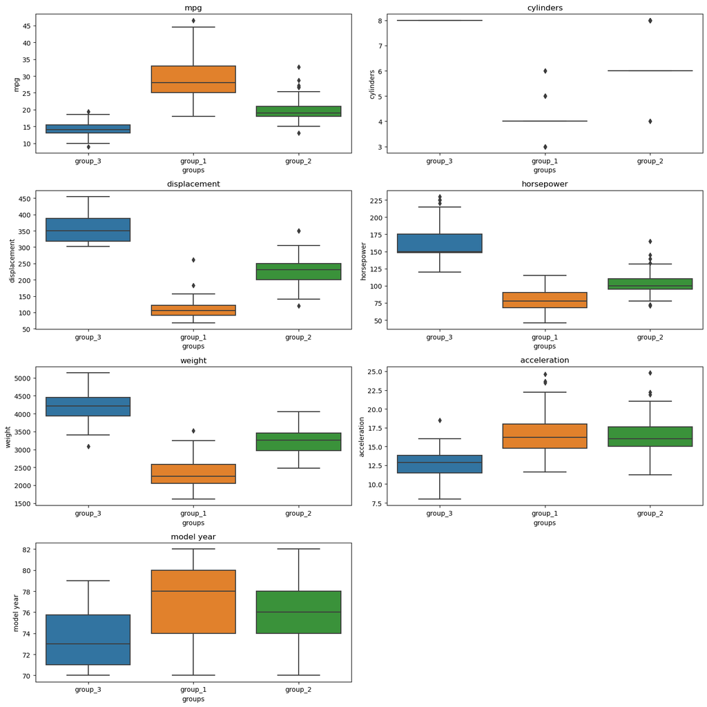

```python
all_col = cars.columns.tolist()

plt.figure(figsize = (15, 15))

for i, variable in enumerate(all_col):
    if i == 7:
        break

    plt.subplot(4, 2, i + 1)

    sns.boxplot(y=cars[variable], x=cars_tsne['groups'])

    plt.tight_layout()

    plt.title(variable)

plt.show()
```

## **Actionable Insights and Recommendations**

### **Vintage cars have an appeal to different audiences**

**According to the data these are the findings:**

**There are 3 groups in the data:**

**There are certain combinations of features that seem to be positively correlated.**

Less relevant: model:specific design or version of a vehicle produced by a particular manufacturer. mpg: fuel efficiency traveled per gallon.

**These are characteristics of each group:**

Group1: Average values: 4 cylinders that go 30 mpg displacement of 100, and horsepower of 80. Weighing approximately 2200 lbs. year model 78. **Smaller, fuel efficient, better mileage. The majority of cars in the database fall under this category.**

Group3: Average values: 8 cylinders that go 15 mpg displacement of 350, and horsepower of 150. Weighing approximately 4200 lbs. year model 73. **powerful engine 8 cylinder but heavy, less fuel efficiency.**